# Test a Perceptual Phenomenon

### Analyzing the Stroop Effect

Perform the analysis in the space below. Remember to follow [the instructions](https://docs.google.com/document/d/1-OkpZLjG_kX9J6LIQ5IltsqMzVWjh36QpnP2RYpVdPU/pub?embedded=True) and review the [project rubric](https://review.udacity.com/#!/rubrics/71/view) before submitting. Once you've completed the analysis and write-up, download this file as a PDF or HTML file, upload that PDF/HTML into the workspace here (click on the orange Jupyter icon in the upper left then Upload), then use the Submit Project button at the bottom of this page. This will create a zip file containing both this .ipynb doc and the PDF/HTML doc that will be submitted for your project.

(1) What is the independent variable? What is the dependent variable?

Independent variable: type of test (congruent words or incongruent words)  
Dependent variable: task time

(2) What is an appropriate set of hypotheses for this task? Specify your null and alternative hypotheses, and clearly define any notation used. Justify your choices.

$H_{0}: \mu_{con} = \mu_{incon}$  
(average times for both types of tests are the same)  
$H_{1}: \mu_{con} \neq \mu_{incon}$  
(average times for those types of tests are different)  
$\mu_{con}$ - mean time of test with congruent words  
$\mu_{incon}$ - mean time of test with incongruent words

(3) Report some descriptive statistics regarding this dataset. Include at least one measure of central tendency and at least one measure of variability. The name of the data file is 'stroopdata.csv'.

```python
import pandas as pd
```

```python
# read data file
df = pd.read_csv("stroopdata.csv")
df.head()
```

|  | Congruent | Incongruent |
| --- | --- | --- |
| 0 | 12.079 | 19.278 |
| 1 | 16.791 | 18.741 |
| 2 | 9.564 | 21.214 |
| 3 | 8.630 | 15.687 |
| 4 | 14.669 | 22.803 |

```python
df.shape
```

```
(24, 2)
```

```python
# calculate mean
con_mean = df["Congruent"].mean()
incon_mean = df["Incongruent"].mean()
con_mean, incon_mean
```

```
(14.051124999999999, 22.015916666666666)
```

```python
# calculate standard deviation
con_std = df["Congruent"].std()
incon_std = df["Incongruent"].std()
con_std, incon_std
```

```
(3.5593579576451955, 4.7970571224691376)
```

By comparing means of two types of tests we can see that on average in our sample incongruent words took more time than congruent.  
Also, looking at standard deviation, the values of time are more spread for incongruent words than for congruent.

(4) Provide one or two visualizations that show the distribution of the sample data. Write one or two sentences noting what you observe about the plot or plots.

```python
import matplotlib.pyplot as plt
% matplotlib inline
```

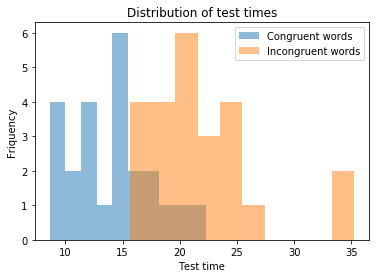

```python
# plot distribution of the sample data
plt.hist(df["Congruent"], alpha=0.5, label="Congruent words")
plt.hist(df["Incongruent"], alpha=0.5, label="Incongruent words")
plt.title("Distribution of test times")
plt.xlabel("Test time")
plt.ylabel("Friquency")
plt.legend()
```

**From this plot we can see that distributions are not normal. We also can see that most of the times for test with congruent words are shorter than with incongruent words.**

(5) Now, perform the statistical test and report your results. What is your confidence level or Type I error associated with your test? What is your conclusion regarding the hypotheses you set up? Did the results match up with your expectations? **Hint:** Think about what is being measured on each individual, and what statistic best captures how an individual reacts in each environment.

We will use t-test, because we have a small sample size (24) and we assume that sample distributions are approximately normal.  
We want to compare means of two related/paired samples, so we will use t-test for related samples.

```python
from scipy import stats

tstat, pval = stats.ttest_rel(df["Congruent"], df["Incongruent"])
tstat, pval
```

```
(-8.020706944109957, 4.1030005857111781e-08)
```

**After running t-test we got p-value = 0.00000004, which means that the probability of Type I error is almost 0. That suggests us to reject null hypothesis and conclude with almost 100% confidence that on average people spend more time for test with incongruent words than with congruent words.**

(6) Optional: What do you think is responsible for the effects observed? Can you think of an alternative or similar task that would result in a similar effect? Some research about the problem will be helpful for thinking about these two questions!